# Modelling First: Data Analysis

Adam Blake

2019-12-03

## Course Description

The data collected for this investigation were collected across two quarters (F18, W19) at the University of California, Los Angeles. Demographic information about the participants is reported in the tables below.

### Combined Demographics

```r
transfer_data %>%
  mutate(sex = fct_explicit_na(sex)) %>%
  count(sex)
```

| sex | n |
| --- | --- |
| Female | 195 |
| Male | 127 |
| Non-binary/Other/Prefer not to answer | 75 |
| (Missing) | 77 |

```r
transfer_data %>%
  mutate(race_ethnic = fct_explicit_na(race_ethnic) %>% fct_lump(5)) %>%
  count(race_ethnic)
```

| race_ethnic | n |
| --- | --- |
| African-American | 158 |
| Asian | 105 |
| Latinx | 42 |
| White | 111 |
| Other | 58 |

### Counts by Term

```r
# Completed the course
transfer_data %>%
  count(term) %>%
  add_row(term = "Total", n = sum(.$n))
```

| term | n |
| --- | --- |
| F18 | 265 |
| W19 | 209 |
| Total | 474 |

```r
# Completed the target items
transfer_data %>%
  select(term, Q1_response, Q2, Q3, Q4, Q5_response, Q6, Q7_response) %>%
  na.omit() %>%
  count(term) %>%
  add_row(term = "Total", n = sum(.$n))
```

| term | n |
| --- | --- |
| F18 | 227 |
| W19 | 202 |
| Total | 429 |

### Comparing Class Performance on Assessments

Each quarter lasted ten weeks during which students completed the full course. Students were scored on their homework completion, and completed five quizzes and a final exam. The relevant questions on transfer were given as an optional extra credit section at the end of the final exam, but for comparison, the mean scores on all of the classwork are given here (values in parentheses indicate the margin of error).

```r
homework_aggregate <- transfer_data %>%
  gather(week, homework, starts_with("hw_")) %>%
  group_by(id) %>%
  summarize(homework = mean(homework, na.rm = TRUE) * 100)

assignment_means <- left_join(transfer_data, homework_aggregate, by = "id") %>%
  group_by(term) %>%
  summarize_at(vars(homework, starts_with("quiz_"), final_exam), mean, na.rm = TRUE) %>%
  gather(assignment, mean, -term) %>%
  spread(term, mean)

assignment_moes <- left_join(transfer_data, homework_aggregate, by = "id") %>%
  group_by(term) %>%
  summarize_at(vars(homework, starts_with("quiz_"), final_exam), moe, na.rm = TRUE) %>%
  gather(assignment, moe, -term) %>%
  spread(term, moe)

tibble(
  Assignment = c("Final Exam", "Homework", paste("Quiz", 1:5)),
  F18 = sprintf("%.2f (%.2f)", assignment_means$F18, assignment_moes$F18),
  W19 = sprintf("%.2f (%.2f)", assignment_means$W19, assignment_moes$W19)
)
```

| Assignment | F18 | W19 |
| --- | --- | --- |
| Final Exam | 88.32 (0.14) | 87.17 (0.18) |
| Homework | 97.34 (0.11) | 96.39 (0.15) |
| Quiz 1 | 90.36 (0.14) | 86.15 (0.28) |
| Quiz 2 | 88.95 (0.16) | 91.05 (0.20) |
| Quiz 3 | 81.36 (0.28) | 82.56 (0.32) |
| Quiz 4 | 90.19 (0.11) | 85.89 (0.29) |
| Quiz 5 | 70.53 (0.35) | 74.05 (0.36) |

## Context

On the final exam, students answered a subset of questions about the `fivethirtyeight::candy_rankings` dataset. In this dataset, `winpercent` is a variable denoting how often a candy is preferred compared to the others it was presented with. There are additionally a number of variables describing different features of the candy like `sugarpercent` (the proportion of sugar in the candy) and `chocolate` (the boolean indicator of whether the candy contained chocolate).

The following seven questions were asked following the final exam in both classes. In this iteration of the course, students had only covered up to single predictor, between-subjects models, including categorical and continuous predictors. These questions all pertained to two-predictor models, e.g. $winpercent_i = \beta_0 + \beta_1 * chocolate_i + \beta_2 * sugarpercent_i$.

## Transfer Items

Before being presented with any of the transfer questions, students were presented with the `lm()` and `supernova()` output for the two models below.

```r
(model_chocolate <- lm(winpercent ~ chocolate, data = candy_rankings))
```

```
##
## Call:
## lm(formula = winpercent ~ chocolate, data = candy_rankings)
##
## Coefficients:
##   (Intercept)  chocolateTRUE
##          42.1           18.8
```

```r
supernova(model_chocolate)
```

```
##  Analysis of Variance Table (Type III SS)
##  Model: winpercent ~ chocolate
##
##                                 SS df       MS      F    PRE     p
##  ----- --------------- | --------- -- -------- ------ ------ -----
##  Model (error reduced) |  7368.542  1 7368.542 56.532 0.4052 .0000
##  Error (from model)    | 10818.492 83  130.343
##  ----- --------------- | --------- -- -------- ------ ------ -----
##  Total (empty model)   | 18187.034 84  216.512
```

```r
(model_sugar <- lm(winpercent ~ sugarpercent, data = candy_rankings))
```

```
##
## Call:
## lm(formula = winpercent ~ sugarpercent, data = candy_rankings)
##
## Coefficients:
##  (Intercept)  sugarpercent
##         44.6          11.9
```

```r
supernova(model_sugar)
```

```
##  Analysis of Variance Table (Type III SS)
##  Model: winpercent ~ sugarpercent
##
##                                 SS df      MS     F    PRE     p
##  ----- --------------- | --------- -- ------- ----- ------ -----
##  Model (error reduced) |   955.002  1 955.002 4.600 0.0525 .0349
##  Error (from model)    | 17232.033 83 207.615
##  ----- --------------- | --------- -- ------- ----- ------ -----
##  Total (empty model)   | 18187.034 84 216.512
```

```r
(model_chocolate_sugar <- lm(winpercent ~ chocolate + sugarpercent, data = candy_rankings))
```

```
##
## Call:
## lm(formula = winpercent ~ chocolate + sugarpercent, data = candy_rankings)
##
## Coefficients:
##   (Intercept)  chocolateTRUE   sugarpercent
##         38.26          18.27           8.57
```

```r
supernova(model_chocolate_sugar)
```

```
##  Analysis of Variance Table (Type III SS)
##  Model: winpercent ~ chocolate + sugarpercent
##
##                                        SS df       MS      F    PRE     p
##  ------------ --------------- | --------- -- -------- ------ ------ -----
##         Model (error reduced) |  7856.127  2 3928.064 31.178 0.4320 .0000
##     chocolate                 |  6901.126  1 6901.126 54.777 0.4005 .0000
##  sugarpercent                 |   487.585  1  487.585  3.870 0.0451 .0525
##         Error (from model)    | 10330.907 82  125.987
##  ------------ --------------- | --------- -- -------- ------ ------ -----
##         Total (empty model)   | 18187.034 84  216.512
```

```r
(model_sugar_chocolate <- lm(winpercent ~ sugarpercent + chocolate, data = candy_rankings))
```

```
##
## Call:
## lm(formula = winpercent ~ sugarpercent + chocolate, data = candy_rankings)
##
## Coefficients:
##   (Intercept)   sugarpercent  chocolateTRUE
##         38.26           8.57          18.27
```

```r
supernova(model_sugar_chocolate)
```

```
##  Analysis of Variance Table (Type III SS)
##  Model: winpercent ~ sugarpercent + chocolate
##
##                                        SS df       MS      F    PRE     p
##  ------------ --------------- | --------- -- -------- ------ ------ -----
##         Model (error reduced) |  7856.127  2 3928.064 31.178 0.4320 .0000
##  sugarpercent                 |   487.585  1  487.585  3.870 0.0451 .0525
##     chocolate                 |  6901.126  1 6901.126 54.777 0.4005 .0000
##         Error (from model)    | 10330.907 82  125.987
##  ------------ --------------- | --------- -- -------- ------ ------ -----
##         Total (empty model)   | 18187.034 84  216.512
```

### Q1: Inventing GLM notation

Question 1 asked students to consider the possibility of creating a single model that included both chocolate and sugarpercent as predictors, and try to “represent the two-predictor model in GLM notation” using regular letters (e.g., b1 for b1, or Xi for Xi). They typed their responses into a standard HTML input box. These responses were first normalized (the normalization function used can be found in the setup code chunk of this file) and the normalized responses were coded inductively by the researchers. The proportions of each coded concept are given in the table below.

```r
transfer_data %>%
  filter(!is.na(Q1_normalized), is.na(Q1_veto)) %>%
  # only look at the scoring columns
  select(starts_with("Q1_"), -Q1_response, -Q1_normalized, -Q1_veto) %>%
  # rename for convenience
  set_names(str_remove(names(.), "^Q1_")) %>%
  # tally / compute proportions
  map_df(mean, na.rm = TRUE) %>%
  select(correct, everything()) %>%
  transpose_tbl() %>%
  set_names(c("concept", "prop."))
```

| concept | prop. |
| --- | --- |
| correct | 0.53596 |
| GLM | 0.98840 |
| y | 0.99304 |
| no_intercept | 0.00464 |
| intercept | 0.99536 |
| one_intercept | 0.92343 |
| two_intercept | 0.07193 |
| two_b | 0.81206 |
| two_x | 0.59861 |
| too_many_x | 0.01392 |

[output cut: 5 more lines]

### Q2-4: Reasoning about PRE, SST, and SSE in the New model

Students were next asked three multiple choice questions asking them to make predictions about PRE, SST, and SSE for the new two-variable model. Questions and a summary of responses are shown below.

```r
mc_summarize <- function(data, column, other_groups = NULL) {
  data %>%
    select_at(vars(column, other_groups)) %>%
    na.omit() %>%
    group_by_at(vars(column, other_groups)) %>%
    summarize(n = n()) %>%
    ungroup()
}

count_to_prop <- function(data, column = "n", na.rm = FALSE) {
  data %>% mutate_at(vars(column), ~ . / sum(., na.rm = na.rm))
}

summaries <- map(
  lst(Q2 = "Q2", Q3 = "Q3", Q4 = "Q4", Q6 = "Q6"),
  ~mc_summarize(transfer_data, .)
)
```

#### PRE

```r
summaries$Q2 %>% count_to_prop()
```

| Q2 | n |
| --- | --- |
| Between the PRE for the chocolate model and that for the sugarpercent model | 0.08924 |
| Can’t tell from the information given | 0.05034 |
| Higher than either the chocolate model or the sugarpercent model | 0.82151 |
| Lower than the PREs for either the chocolate model or the sugarpercent model | 0.03890 |

```r
summaries$Q2 %>% select(n) %>% chisq.test()
```

```
##
##  Chi-squared test for given probabilities
##
## data:  .
## X-squared = 764, df = 3, p-value <2e-16
```

#### SST

```r
summaries$Q3 %>% count_to_prop()
```

| Q3 | n |
| --- | --- |
| Can’t tell from the information given | 0.01822 |
| Higher than that of the chocolate model and the sugarpercent model | 0.15262 |
| Lower than that of the chocolate model and the sugarpercent model | 0.05923 |
| The same as both the chocolate model and the sugarpercent model | 0.76993 |

```r
summaries$Q3 %>% select(n) %>% chisq.test()
```

```
##
##  Chi-squared test for given probabilities
##
## data:  .
## X-squared = 650, df = 3, p-value <2e-16
```

#### SSE

```r
summaries$Q4 %>% count_to_prop()
```

| Q4 | n |
| --- | --- |
| Higher than that of either the chocolate model or the sugarpercent model | 0.12073 |
| Lower than that of either the chocolate model or the sugarpercent model | 0.84510 |
| The same as that of the chocolate model | 0.01822 |
| The same as that of the sugarpercent model | 0.01595 |

```r
summaries$Q4 %>% select(n) %>% chisq.test()
```

```
##
##  Chi-squared test for given probabilities
##
## data:  .
## X-squared = 842, df = 3, p-value <2e-16
```

### Q5: Why is the SSE for the new model smaller?

After answering the previous questions, students moved on to a new page on which they were informed that, in fact, the SSE is lower for the two-predictor model than for either of the single-predictor models (they were prevented from navigating back to modify their answer to the prior question). Given this new information, students were asked on an open-response question why they thought the SSE for the two-predictor model would be smaller. These responses were again coded inductively by the authors, and the proportions of each coded concept are given in the table below.

```r
transfer_data %>%
  filter(!is.na(Q5_response)) %>%
  # only look at the scoring columns
  select(starts_with("Q5_"), -Q5_response, -Q5_notes) %>%
  # rename for convenience
  set_names(str_remove(names(.), "^Q5_")) %>%
  # tally / compute proportions
  map_df(mean, na.rm = TRUE) %>%
  transpose_tbl() %>%
  set_names(c("concept", "prop."))
```

| concept | prop. |
| --- | --- |
| multiple explanatory variables /more complex | 0.62676 |
| explain more variation/error | 0.69484 |
| ss model larger | 0.20188 |
| ss total same | 0.07042 |
| less error left | 0.18075 |
| not necessarily better | 0.02347 |
| cost of variables | 0.02817 |
| overlap | 0.01878 |
| pre larger | 0.04225 |
| distance to model / deviation from the model | 0.07981 |

[output cut: 4 more lines]

### Q6: Making predictions with new model

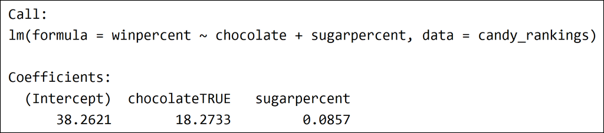

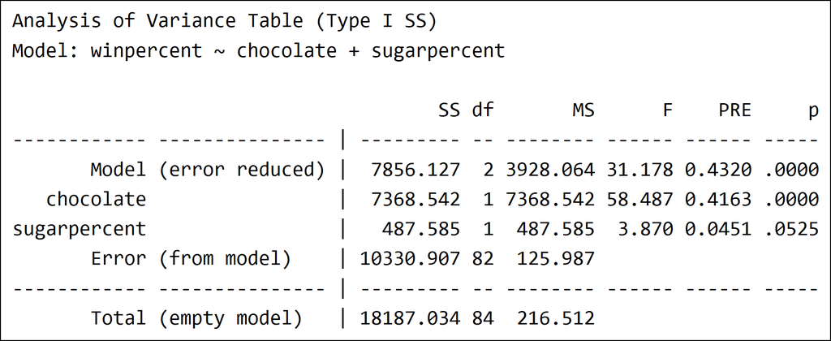

```r
summaries$Q6 %>% count_to_prop()
```

| Q6 | n |
| --- | --- |
| 38.26 + 18.27 | 0.44191 |
| 38.26 + 18.27 + 0.0857 | 0.06834 |
| 38.26 + 18.27 + 0.0857*sugarpercent | 0.47836 |
| Can’t tell from the output above | 0.01139 |

### Q7: Why is the ANOVA table for the chocolate then sugar model different from the sugar then chocolate model?

Finally, students were queried about the effect of sequentially adding variables into a complex model. Students were told that we ran two models where the order of the predictor variables was flipped. That is, in the first output below, they were shown the model where chocolate was entered first then sugar percent. In the next output, they were shown the model where sugar percent was entered before chocolate. Question 7 asked students to explain why the ANOVA tables showed different values depending on which variable was entered into the model first. These responses were again coded inductively by the authors, and the proportions of each coded concept are given in the table below the outputs.

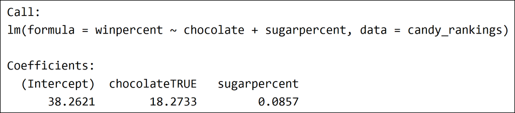

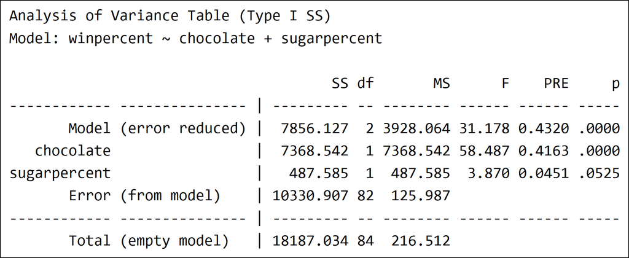

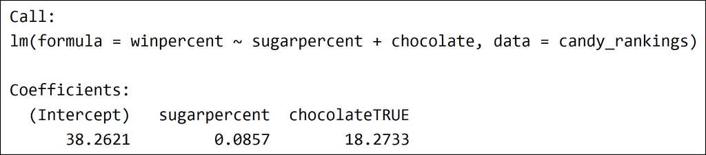

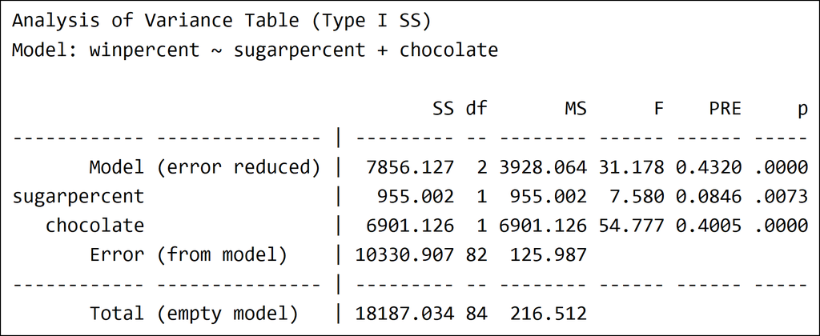

| concept | prop. |
| --- | --- |
| first variable has more | 0.308057 |
| second variable has leftover (first is taken out) | 0.265403 |
| SS Model / PRE has different opportunity / variation to explain | 0.187204 |
| overlapping variation | 0.097156 |
| first gets overlap | 0.040284 |
| sampling variation | 0.094787 |
| reversed explanatory / outcome | 0.040284 |
| one variable is better | 0.116114 |
| coefficients change | 0.047393 |
| misunderstood | 0.049763 |

[output cut: 3 more lines]

#### How many students included at least one of the correct concepts?

```r
correct_concepts <- c(
  "first variable has more",
  "second variable has leftover (first is taken out)",
  "SS Model / PRE has different opportunity / variation to explain",
  "overlapping variation"
)

q7_mis_dna  <- q7_data %>%
  mutate(mis_dna = misunderstood | `did not attempt`) %>%
  {mean(.$mis_dna, na.rm = TRUE)}

q7_data %>%
  select(one_of(correct_concepts)) %>%
  transmute(one_correct = rowSums(.) > 0) %>%
  summarize(one_correct = mean(one_correct, na.rm = TRUE)) %>%
  mutate(mis_dna = q7_mis_dna, zero_correct = 1 - q7_mis_dna - one_correct)
```

| one_correct | mis_dna | zero_correct |
| --- | --- | --- |
| 0.4052 | 0.05924 | 0.5355 |

# Auxillary Analyses

## Comparisons By Term

These are all of the summary tables from above, but split by the class the data was pulled from (F18, W19).

### Q1: By Term

```r
transfer_data %>%
  filter(!is.na(Q1_normalized), is.na(Q1_veto)) %>%
  # only look at the scoring columns
  select(term, starts_with("Q1_"), -Q1_response, -Q1_normalized, -Q1_veto) %>%
  # rename for convenience
  set_names(str_remove(names(.), "^Q1_")) %>%
  # tally / compute proportions
  group_by(term) %>%
  summarize_all(mean, na.rm = TRUE) %>%
  select(term, correct, everything()) %>%
  transpose_tbl() %>%
  {.[2:nrow(.), ]} %>%
  set_names(c("concept", "F18", "W19"))
```

| concept | F18 | W19 |
| --- | --- | --- |
| correct | 0.5764 | 0.4901 |
| GLM | 0.9956 | 0.9802 |
| y | 0.9956 | 0.9901 |
| no_intercept | 0.004367 | 0.004950 |
| intercept | 0.9956 | 0.9950 |
| one_intercept | 0.9214 | 0.9257 |
| two_intercept | 0.07424 | 0.06931 |
| two_b | 0.8297 | 0.7921 |
| two_x | 0.6463 | 0.5446 |
| too_many_x | 0.01310 | 0.01485 |

[output cut: 5 more lines]

### Q2-4 by term

```r
summaries_by_term <- map(
  lst(Q2 = "Q2", Q3 = "Q3", Q4 = "Q4", Q6 = "Q6"),
  function(x) mc_summarize(transfer_data, x, "term") %>% spread(term, n)
)
```

#### PRE

```r
summaries_by_term$Q2 %>% count_to_prop(c("F18", "W19"))
```

| Q2 | F18 | W19 |
| --- | --- | --- |
| Between the PRE for the chocolate model and that for the sugarpercent model | 0.09442 | 0.08333 |
| Can’t tell from the information given | 0.03863 | 0.06373 |
| Higher than either the chocolate model or the sugarpercent model | 0.81116 | 0.83333 |
| Lower than the PREs for either the chocolate model or the sugarpercent model | 0.05579 | 0.01961 |

#### SST

```r
summaries_by_term$Q3 %>% count_to_prop(c("F18", "W19"))
```

| Q3 | F18 | W19 |
| --- | --- | --- |
| Can’t tell from the information given | 0.004292 | 0.03398 |
| Higher than that of the chocolate model and the sugarpercent model | 0.145923 | 0.16019 |
| Lower than that of the chocolate model and the sugarpercent model | 0.072961 | 0.04369 |
| The same as both the chocolate model and the sugarpercent model | 0.776824 | 0.76214 |

#### SSE

```r
summaries_by_term$Q4 %>% count_to_prop(c("F18", "W19"))
```

| Q4 | F18 | W19 |
| --- | --- | --- |
| Higher than that of either the chocolate model or the sugarpercent model | 0.12876 | 0.11165 |
| Lower than that of either the chocolate model or the sugarpercent model | 0.83691 | 0.85437 |
| The same as that of the chocolate model | 0.02146 | 0.01456 |
| The same as that of the sugarpercent model | 0.01288 | 0.01942 |

### Q5 by term

```r
transfer_data %>%
  filter(!is.na(Q5_response)) %>%
  # only look at the scoring columns
  select(term, starts_with("Q5_"), -Q5_response, -Q5_notes) %>%
  # rename for convenience
  set_names(str_remove(names(.), "^Q5_")) %>%
  # tally / compute proportions
  group_by(term) %>%
  summarize_all(mean, na.rm = TRUE) %>%
  # select(term, correct, everything()) %>%
  transpose_tbl() %>%
  {.[2:nrow(.), ]} %>%
  set_names(c("concept", "F18", "W19"))
```

| concept | F18 | W19 |
| --- | --- | --- |
| multiple explanatory variables /more complex | 0.5619 | 0.7000 |
| explain more variation/error | 0.6239 | 0.7750 |
| ss model larger | 0.1991 | 0.2050 |
| ss total same | 0.0708 | 0.0700 |
| less error left | 0.1858 | 0.1750 |
| not necessarily better | 0.02655 | 0.02000 |
| cost of variables | 0.0354 | 0.0200 |
| overlap | 0.02655 | 0.01000 |
| pre larger | 0.04425 | 0.04000 |
| distance to model / deviation from the model | 0.0885 | 0.0700 |

[output cut: 4 more lines]

### Q6 by term

```r
summaries_by_term$Q6 %>% count_to_prop(c("F18", "W19"))
```

| Q6 | F18 | W19 |
| --- | --- | --- |
| 38.26 + 18.27 | 0.467811 | 0.41262 |
| 38.26 + 18.27 + 0.0857 | 0.077253 | 0.05825 |
| 38.26 + 18.27 + 0.0857*sugarpercent | 0.446352 | 0.51456 |
| Can’t tell from the output above | 0.008584 | 0.01456 |

```r
summaries_by_term$Q6 %>% select(F18) %>% chisq.test()
```

```
##
##  Chi-squared test for given probabilities
##
## data:  .
## X-squared = 162, df = 3, p-value <2e-16
```

```r
summaries_by_term$Q6 %>% select(W19) %>% chisq.test()
```

```
##
##  Chi-squared test for given probabilities
##
## data:  .
## X-squared = 155, df = 3, p-value <2e-16
```

### Q7 by term

```r
transfer_data %>%
  filter(!is.na(Q7_response)) %>%
  # only look at the scoring columns
  select(term, starts_with("Q7_"), -Q7_response, -Q7_notes) %>%
  # rename for convenience
  set_names(str_remove(names(.), "^Q7_")) %>%
  # tally / compute proportions
  mutate(none_of_these = rowSums(select(., -term)) == 0) %>%
  group_by(term) %>%
  summarize_all(mean, na.rm = TRUE) %>%
  transpose_tbl() %>%
  {.[2:nrow(.), ]} %>%
  set_names(c("concept", "F18", "W19"))
```

| concept | F18 | W19 |
| --- | --- | --- |
| first variable has more | 0.2466 | 0.3769 |
| second variable has leftover (first is taken out) | 0.1883 | 0.3518 |
| SS Model / PRE has different opportunity / variation to explain | 0.2063 | 0.1658 |
| overlapping variation | 0.08072 | 0.11558 |
| first gets overlap | 0.02691 | 0.05528 |
| sampling variation | 0.07175 | 0.12060 |
| reversed explanatory / outcome | 0.04036 | 0.04020 |
| one variable is better | 0.13901 | 0.09045 |
| coefficients change | 0.05830 | 0.03518 |
| misunderstood | 0.05381 | 0.04523 |

[output cut: 3 more lines]

## Correlations with Performance

```r
transfer_data_scored <- transfer_data %>%
  mutate(
    Q1_score = (Q1_GLM + Q1_proper_subscripts + Q1_y +  Q1_one_intercept +
                  Q1_two_b + Q1_two_x +  Q1_error) / 7,
    Q2_score = str_detect(Q2, "^Higher") %>% as.integer(),
    Q3_score = str_detect(Q3, "^The same") %>% as.integer(),
    Q4_score = str_detect(Q4, "^Lower") %>% as.integer(),
    Q5_score = (`Q5_explain more variation/error` + `Q5_ss model larger` +
                  `Q5_distance to model / deviation from the model` +
                  `Q5_ss total same`) / 4,
    Q6_score = str_detect(Q6, "sugarpercent$") %>% as.integer(),
    Q7_score = (`Q7_first variable has more` + `Q7_second variable has leftover (first is taken out)` +
                  `Q7_SS Model / PRE has different opportunity / variation to explain` +
                  `Q7_overlapping variation`) / 4
  ) %>%
  select(id, ends_with("_score"))
```

### Correlation with Final Exam Performance

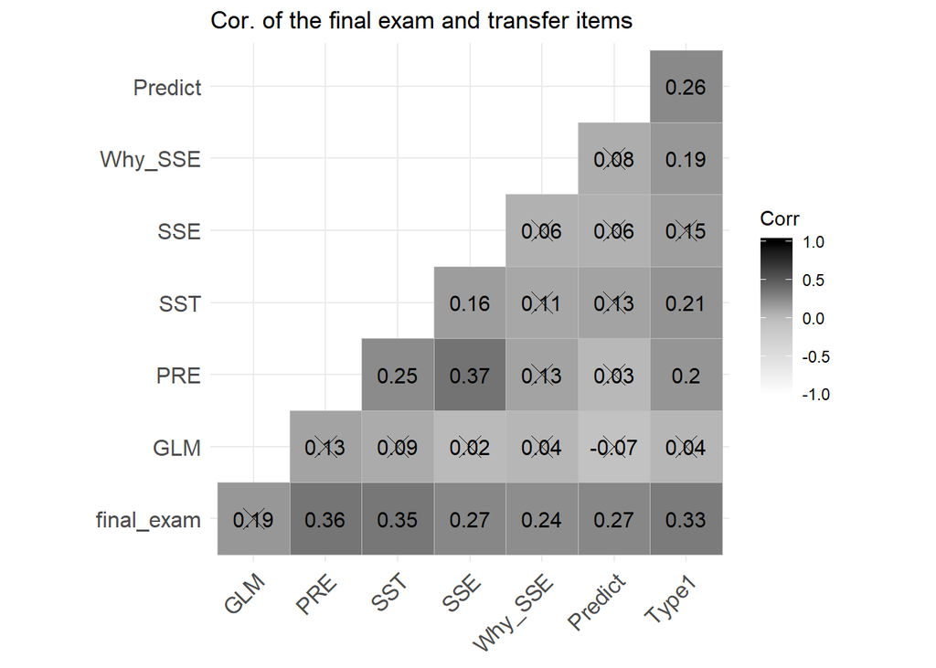

```r
response_matrix <- transfer_data %>%
  select(id, final_exam) %>%
  left_join(transfer_data_scored, by = "id") %>%
  select(-id, GLM = Q1_score, PRE = Q2_score, SST = Q3_score, SSE = Q4_score,
         Why_SSE = Q5_score, Predict = Q6_score, Type1 = Q7_score)

response_matrix %>%
  cor(use = "complete.obs") %>%
  ggcorrplot(
    title = "Cor. of the final exam and transfer items",
    type = "lower",
    lab = TRUE,
    colors = c("white", "grey", "black"),
    p.mat = cor_pmat(response_matrix, use = "complete.obs"),
    sig.level = .0001
  )
```

### Do similar items from the final predict performance on Q6?

The following three questions were asked on the final and directly relate to understanding how to make a prediction using model coefficients.

**1)** Based on this chocolate model, what would the predicted value of winpercent be for candies that contain chocolate?

```
##
## Call:
## lm(formula = winpercent ~ chocolate, data = candy_rankings)
##
## Coefficients:
##   (Intercept)  chocolateTRUE
##          42.1           18.8
```

**2)** We fit another model (the “**fruity** model”) using the same approach we used with **chocolate**. The parameter estimates for the two models are in the table above. How should we interpret the negative estimate (-11.21) for the **fruity** parameter?

```
##
## Call:
## lm(formula = winpercent ~ fruity, data = candy_rankings)
##
## Coefficients:
## (Intercept)   fruityTRUE
##        55.3        -11.2
```

**3)** Fitting the model of winpercent explained by sugarpercent yields the following parameter estimates: $b_0 = 44.61$; $b_1 = .1192$. If a candy has a sugarpercent of 90, what would you predict its winpercent to be?

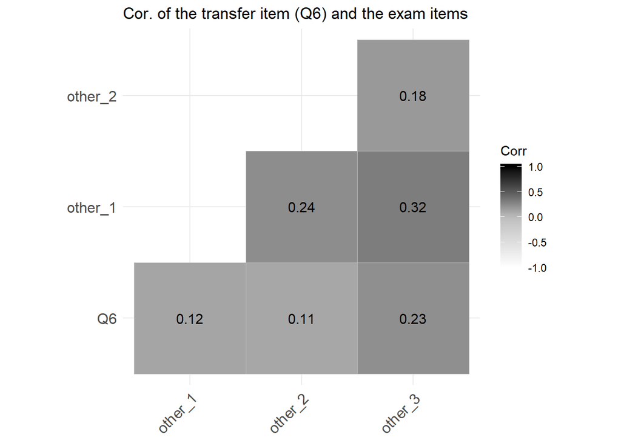

```r
other_data %>%
  mutate(
    Q19 = str_detect(Q19, "42\\.14 \\+ 18\\.78") %>% as.integer(),
    Q21 = str_detect(Q21, "The negative number shows .+ having fruit .+ candy less likely to win") %>%
      as.integer(),
    Q40 = str_detect(Q40, "55") %>% as.integer()
  ) %>%
  right_join(transfer_data_scored %>% select(id, Q6_score), by = "id") %>%
  select(Q6 = Q6_score, other_1 = Q19, other_2 = Q21, other_3 = Q40) %>%
  cor(method = "spearman", use = "complete.obs") %>%
  ggcorrplot(
    title = "Cor. of the transfer item (Q6) and the exam items",
    type = "lower",
    lab = TRUE,
    colors = c("white", "grey", "black")
  )
```